# Biostat 203B Homework 4

Due Mar 19 @ 11:59PM

Juliet Yixuan Zhou

Load database libraries and the tidyverse frontend:

```r
#install.packages("caret")

library(tidyverse)
library(lubridate)
library(miceRanger)
library(readr)
library(caret)
library(randomForest)
library(keras)
```

## Q1. Missing data

Through the Shiny app developed in HW3, we observe abundant missing values in the MIMIC-IV ICU cohort we created. In this question, we use multiple imputation to obtain a data set without missing values.

0. Read following tutorials on the R package miceRanger for imputation: https://github.com/farrellday/miceRanger, https://cran.r-project.org/web/packages/miceRanger/vignettes/miceAlgorithm.html.

   A more thorough book treatment of the practical imputation strategies is the book [*Flexible Imputation of Missing Data*](https://stefvanbuuren.name/fimd/) by Stef van Buuren.
1. Explain the jargon MCAR, MAR, and MNAR.

**Solution**: MCAR refers to data being Missing Completely At Random, which suggests that the causes of missing data are unrelated to the data itself. MAR refers to data being Missing At Random, which suggests that the probability of having missing data is the same within groups defined by the observed data, and might be different between groups. MNAR refers to data being Missing Not At Random, which suggests that the probability of having missing data varies for reasons that are unknown.

2. Explain in a couple of sentences how the Multiple Imputation by Chained Equations (MICE) work.

**Solution**: For a dataset with p variables, replace the missing values for each variable with placeholders, e.g. mean of the not missing observations for each variable. Set the placeholders of one of these variables back to missing, and use this variable as the dependent variable in a regression model and all the other variables as predictors. Use this model to predict and replace missing values for this variable. Repeat this process for all the variables, and then repeat the whole process for several cycles.

3. Perform a data quality check of the ICU stays data. Discard variables with substantial missingness, say >5000 `NA`s. Replace apparent data entry errors by `NA`s.

**Solution**:

```r
icu <- read_rds("/Users/julietzhou/Documents/R/HW3_Shiny/icu_cohort.rds")
# if knitting on server:
# icu <- read_rds("../hw3/mimiciv_shiny/icu_cohort.rds")

# print the variables with > 5000 missing values
missing_var <- as_tibble(cbind(col_names = colnames(icu),
                       missing = colSums(is.na(icu)) > 5000)) %>%
  filter(missing == TRUE) %>%
  print()
```

```
## # A tibble: 7 x 2
##   col_names                        missing
##   <chr>                            <chr>
## 1 deathtime                        TRUE
## 2 edregtime                        TRUE
## 3 edouttime                        TRUE
## 4 dod                              TRUE
## 5 lactate                          TRUE
## 6 arterial_blood_pressure_systolic TRUE
## 7 arterial_blood_pressure_mean     TRUE
```

```r
# remove these variables
icu <- icu %>%
  select(-missing_var$col_names)
```

For lab measurements, not enough information is available to determine the range of abnormal values, therefore these variables are kept as they are. For vital measurements, physically impossible values are replaced with `NA`s.

```r
# For vitals, the following measurements are replaced with NA:

icu <- icu %>%
  mutate(
    # temperature_fahrenheit < 70
    temperature_fahrenheit =
      ifelse(temperature_fahrenheit < 70,
             NA, temperature_fahrenheit),
    # heart_rate > 800
    heart_rate = ifelse(heart_rate > 800, NA, heart_rate),
    # non_invasive_blood_pressure_systolic > 10000
    non_invasive_blood_pressure_systolic =
      ifelse(non_invasive_blood_pressure_systolic > 10000, NA,
             non_invasive_blood_pressure_systolic),
    # non_invasive_blood_pressure_mean > 800
    non_invasive_blood_pressure_mean =
      ifelse(non_invasive_blood_pressure_mean > 800, NA,
             non_invasive_blood_pressure_mean))
```

4. Impute missing values by `miceRanger` (request $m=3$ datasets). This step is very computational intensive. Make sure to save the imputation results as a file.

**Solution**: The code for imputation is not run in order to shorten the knitting time. The final mice object and the imputed datasets are saved locally, and called in later steps.

```r
icu <- icu %>%
  # only keep variables that are going to be used in Q2
  select(death_within_30days, # outcome variable
         gender, age_at_adm, marital_status, ethnicity, # demographics
         # first lab measurements
         bicarbonate, calcium, chloride, creatinine, glucose, magnesium,
         potassium, sodium, hematocrit, wbc,
         # first vital measurements
         heart_rate, non_invasive_blood_pressure_systolic,
         non_invasive_blood_pressure_mean, respiratory_rate,
         temperature_fahrenheit)
```

```r
system.time(
  miceObj <- miceRanger(
    icu,
    m = 3,
    max.depth = 10,
    returnModels = TRUE,
    verbose = FALSE)
)

# save the imputed objects
dataList <- completeData(miceObj)
saveRDS(dataList, file = "/Users/julietzhou/Documents/R/HW4/miceData_full.rds")
saveRDS(miceObj, file = "/Users/julietzhou/Documents/R/HW4/miceObj.rds")
```

5. Make imputation diagnostic plots and explain what they mean.

**Solution**: The first plot compares the imputed distributions (black) with the original distribution (red) for each variable.

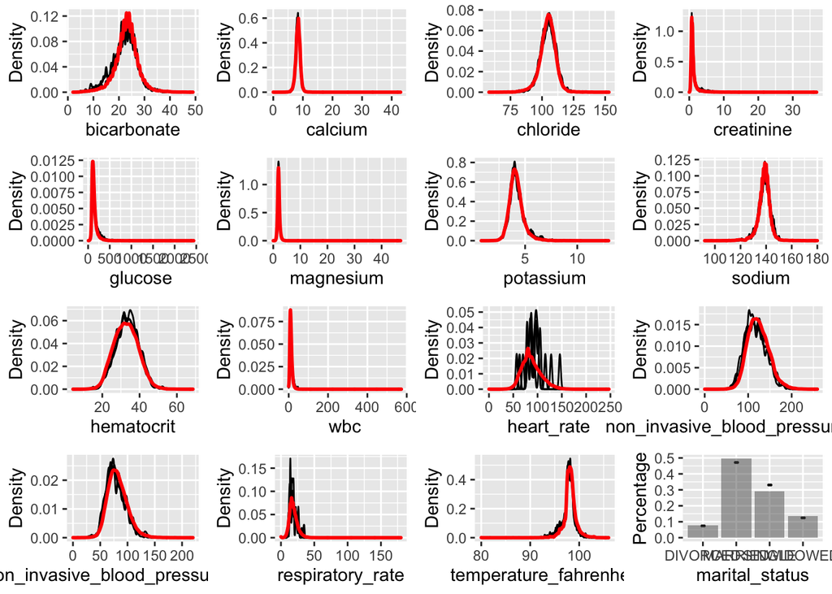

```r
miceObj <- read_rds("/Users/julietzhou/Documents/R/HW4/miceObj.rds")

plotDistributions(miceObj)
```

The second plot examines the convergence of correlation between imputed values in every combination of datasets over several iterations. For some of the variables, there appears to be convergence going on, while for others, convergence is not achieved over 5 iterations. This may be due to specifying `max.depth = 10` because of limited computational power.

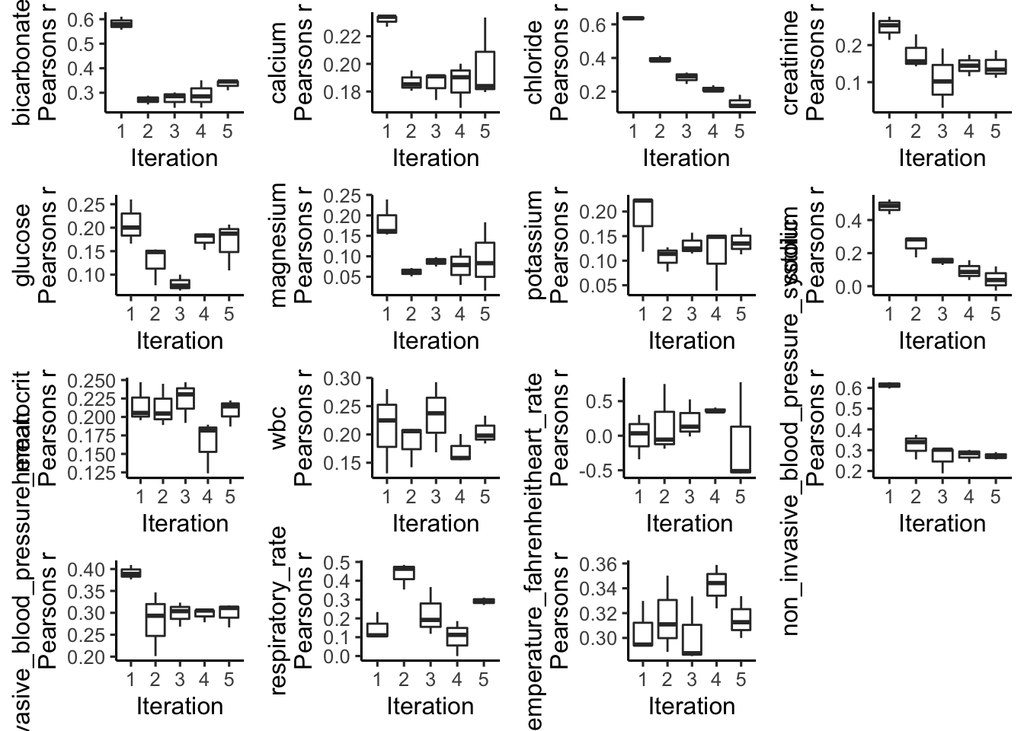

```r
plotCorrelations(miceObj, vars = 'allNumeric')
```

The third plot examines the convergence of values (mean and SD) for each variable over iterations. For some variables, such as bicarbonate, chloride, and non invasive mean blood pressure, appear to be converging, while some variables are not able to converge.

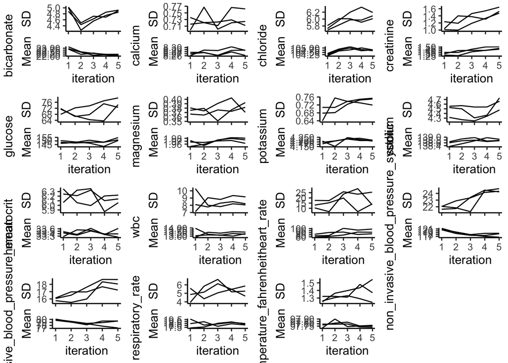

```r
plotVarConvergence(miceObj,vars = 'allNumeric')
```

The last plot examines the OOB model error for the variables over all iterations. We can see that most of the variables have trouble converging, suggesting that the variables might be imputed with a less than adequate degree of accuracy.

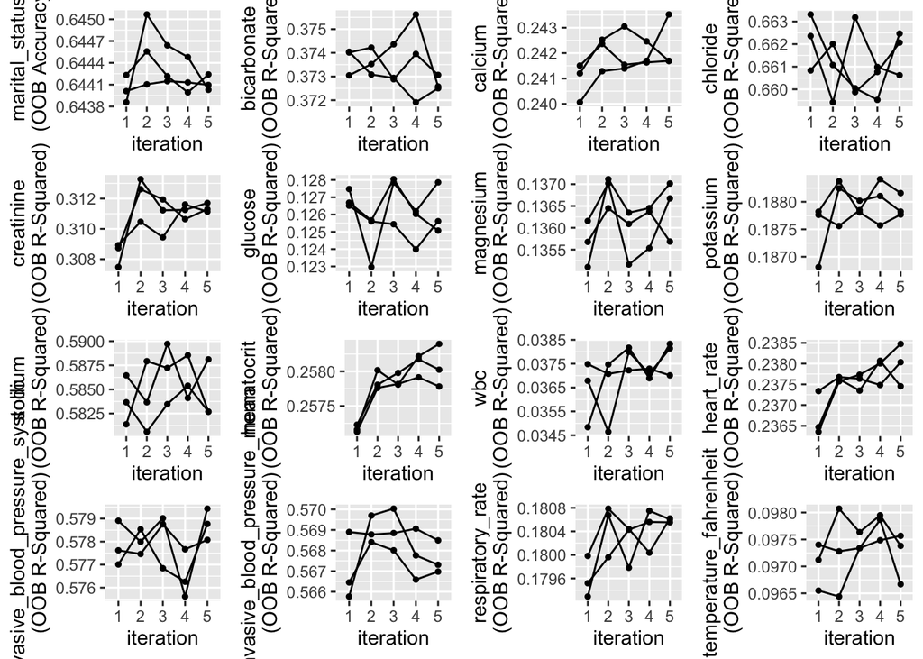

```r
plotModelError(miceObj)
```

```r
remove(miceObj)
```

6. Obtain a complete data set by averaging the 3 imputed data sets.

**Solution**:

```r
dataList <- read_rds("/Users/julietzhou/Documents/R/HW4/miceData_full.rds")

# set up the model formula
xnam <- names(icu)[2:20]
fmla <- as.formula(paste("death_within_30days ~ ", paste(xnam, collapse = "+")))

# obtain the model matrix from each data set, and average the three matrices
dm1 <- model.matrix(fmla, data = dataList$Dataset_1)
dm2 <- model.matrix(fmla, data = dataList$Dataset_2)
dm3 <- model.matrix(fmla, data = dataList$Dataset_3)

dm_avg <- (dm1 + dm2 + dm3)/3

# bind the averaged model matrix with outcome variable
finaldata <- cbind(
  death_within_30days = as.numeric(dataList$Dataset_1$death_within_30days),
  as.data.frame(dm_avg))

remove(dm1, dm2, dm3, dm_avg)
```

## Q2. Predicting 30-day mortality

Develop at least two analytic approaches for predicting the 30-day mortality of patients admitted to ICU using demographic information (gender, age, marital status, ethnicity), first lab measurements during ICU stay, and first vital measurements during ICU stay. For example, you can use (1) logistic regression (`glm()` function), (2) logistic regression with lasso penalty (glmnet package), (3) random forest (randomForest package), or (4) neural network.

1. Partition data into 80% training set and 20% test set. Stratify partitioning according the 30-day mortality status.

**Solution**:

```r
set.seed(1245)
# partition data
train_index <- createDataPartition(
  finaldata$death_within_30days,
  p = 0.8,
  list = FALSE)

# the following data sets (train/test) can be used directly in logistic models
icu_train <- finaldata[train_index, ]
icu_test <- finaldata[-train_index, ]

# the following steps format data for neural networks
icu_train_x <- subset(icu_train, select = -death_within_30days)
icu_train_x <- as.matrix(icu_train_x)

icu_train_y <- icu_train$death_within_30days

icu_test_x <- subset(icu_test, select = -death_within_30days)
icu_test_x <- as.matrix(icu_test_x)

icu_test_y <- icu_test$death_within_30days
```

2. Train the models using the training set.

**Solution**:

```r
# Model 1: logistic model

# fit the model
set.seed(1245)
logit_model <- train(as.character(death_within_30days) ~. + 0,
                     data = icu_train,
                     method = "glm",
                     family = binomial(link = "logit"))
```

```r
# Model 2: logistic model with lasso penalty
# install.packages("glmnet")
library(glmnet)
set.seed(1245)

# find the best lambda using cross-validation
cv.lasso <- cv.glmnet(icu_train_x, icu_train_y, alpha = 1, family = "binomial")

# fit the model on the training data
lasso_model <- glmnet(icu_train_x, icu_train_y,
                      family = "binomial", alpha = 1,
                      lambda = cv.lasso$lambda.min)
```

```r
# Model 4: neural networks

set.seed(1245)

# specify model
nn_model <- keras_model_sequential()
nn_model %>%
  layer_dense(units = 8, activation = 'relu',
              input_shape = ncol(icu_train_x)) %>%
  layer_dropout(rate = 0.4) %>%
  layer_dense(units = 8, activation = 'relu') %>%
  layer_dropout(rate = 0.3) %>%
  layer_dense(units = 1, activation = 'sigmoid')

nn_model %>% compile(
  loss = loss_binary_crossentropy,
  optimizer = "adam",
  metrics = "binary_accuracy")

# fit the model on the training data
system.time({
history_icu <- nn_model %>% fit(
  x = icu_train_x, y = icu_train_y,
  epochs = 30, batch_size = 128,
  validation_split = 0.2
)
})
```

```
##    user  system elapsed
##  11.670   0.949   9.684
```

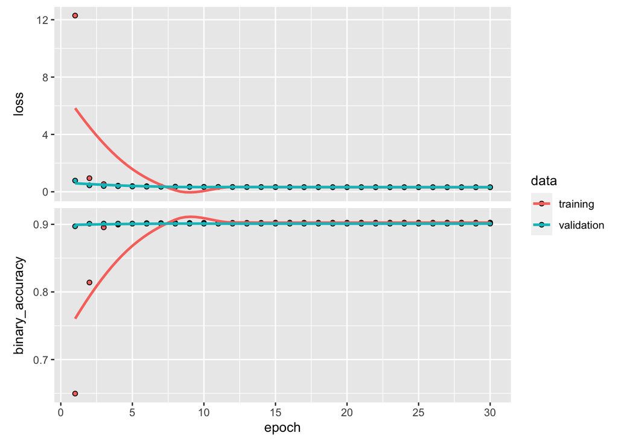

```r
plot(history_icu)
```

3. Compare model prediction performance on the test set.

**Solution**: The first logistic model returns an accuracy of 0.9040424. With lasso penalty, the accuracy is 0.9034421 The model using neural network returns an accuracy of 0.9013408. Overall, the three models all return similar results.

```r
# Model 1: logistic model

# make predictions on the test data
logit_pred <- predict(logit_model, newdata = icu_test)

# calculate model accuracy
logit_accuracy <- table(logit_pred, icu_test[,"death_within_30days"])
sum(diag(logit_accuracy))/sum(logit_accuracy)
```

```
## [1] 0.9040424
```

```r
# Model 2: logistic model with lasso penalty

# make predictions on the test data
lasso_prob <- lasso_model %>% predict(newx = icu_test_x)
lasso_pred <- ifelse(lasso_prob > 0.5, 1, 0)

# calculate model accuracy
mean(lasso_pred == icu_test_y)
```

```
## [1] 0.9034421
```

```r
# Model 4: neural networks

# calculate model accuracy
nn_model %>% evaluate(icu_test_x, icu_test_y)
```

```
##            loss binary_accuracy
##       0.3196077       0.9013408
```